# Asssignment4

Chaytanya Kumar

2022-11-28

Solution 1 and Solution 2 are on the Paper

This problem involves the OJ (orange juice) data set which is part of the ISLR2 package. library(ISLR2); attach(OJ); To find its description, type ?OJ (a) Create a training set containing a random sample of 800 observations, and a test set containing the remaining observations.

```r
library(ISLR2)
library(tree)
summary(OJ)
```

```
##  Purchase WeekofPurchase     StoreID        PriceCH         PriceMM
##  CH:653   Min.   :227.0   Min.   :1.00   Min.   :1.690   Min.   :1.690
##  MM:417   1st Qu.:240.0   1st Qu.:2.00   1st Qu.:1.790   1st Qu.:1.990
##           Median :257.0   Median :3.00   Median :1.860   Median :2.090
##           Mean   :254.4   Mean   :3.96   Mean   :1.867   Mean   :2.085
##           3rd Qu.:268.0   3rd Qu.:7.00   3rd Qu.:1.990   3rd Qu.:2.180
##           Max.   :278.0   Max.   :7.00   Max.   :2.090   Max.   :2.290
##      DiscCH            DiscMM         SpecialCH        SpecialMM
##  Min.   :0.00000   Min.   :0.0000   Min.   :0.0000   Min.   :0.0000
##  1st Qu.:0.00000   1st Qu.:0.0000   1st Qu.:0.0000   1st Qu.:0.0000
##  Median :0.00000   Median :0.0000   Median :0.0000   Median :0.0000
##  Mean   :0.05186   Mean   :0.1234   Mean   :0.1477   Mean   :0.1617
##  3rd Qu.:0.00000   3rd Qu.:0.2300   3rd Qu.:0.0000   3rd Qu.:0.0000
##  Max.   :0.50000   Max.   :0.8000   Max.   :1.0000   Max.   :1.0000
##     LoyalCH          SalePriceMM     SalePriceCH      PriceDiff       Store7
##  Min.   :0.000011   Min.   :1.190   Min.   :1.390   Min.   :-0.6700   No :714
##  1st Qu.:0.325257   1st Qu.:1.690   1st Qu.:1.750   1st Qu.: 0.0000   Yes:356
##  Median :0.600000   Median :2.090   Median :1.860   Median : 0.2300
##  Mean   :0.565782   Mean   :1.962   Mean   :1.816   Mean   : 0.1465
##  3rd Qu.:0.850873   3rd Qu.:2.130   3rd Qu.:1.890   3rd Qu.: 0.3200
##  Max.   :0.999947   Max.   :2.290   Max.   :2.090   Max.   : 0.6400
##    PctDiscMM        PctDiscCH       ListPriceDiff       STORE
##  Min.   :0.0000   Min.   :0.00000   Min.   :0.000   Min.   :0.000
##  1st Qu.:0.0000   1st Qu.:0.00000   1st Qu.:0.140   1st Qu.:0.000
##  Median :0.0000   Median :0.00000   Median :0.240   Median :2.000
##  Mean   :0.0593   Mean   :0.02731   Mean   :0.218   Mean   :1.631
##  3rd Qu.:0.1127   3rd Qu.:0.00000   3rd Qu.:0.300   3rd Qu.:3.000
##  Max.   :0.4020   Max.   :0.25269   Max.   :0.440   Max.   :4.000
```

```r
set.seed(1)

Z <- sample(1:nrow(OJ), 800)

train <- OJ[Z, ]   #Splitting it into traning set and testing set
test <- OJ[-Z, ]
```

2. Fit a tree to the training data, with Purchase as the response and the other variables as predictors. Use the summary() function to produce summary statistics about the tree, and describe the results obtained. What is the training error rate? How many terminal nodes does the tree have?

```r
tree_model <- tree(Purchase ~ ., train)
summary(tree_model)
```

```
##
## Classification tree:
## tree(formula = Purchase ~ ., data = train)
## Variables actually used in tree construction:
## [1] "LoyalCH"       "PriceDiff"     "SpecialCH"     "ListPriceDiff"
## [5] "PctDiscMM"
## Number of terminal nodes:  9
## Residual mean deviance:  0.7432 = 587.8 / 791
## Misclassification error rate: 0.1588 = 127 / 800
```

Looking at the output, From all the variables, only 5 of the variables were split i.e. “LoyalCH” , “PriceDiff” , “SpecialCH” ,“ListPriceDiff”,“PctDiscMM”. The training error rate is 15.88%.and Number of terminal nodes = 9

3. Type in the name of the tree object in order to get a detailed text output. Pick one of the terminal nodes, and interpret the information displayed.

```r
tree_model
```

```
## node), split, n, deviance, yval, (yprob)
##       * denotes terminal node
##
##  1) root 800 1073.00 CH ( 0.60625 0.39375 )
##    2) LoyalCH < 0.5036 365  441.60 MM ( 0.29315 0.70685 )
##      4) LoyalCH < 0.280875 177  140.50 MM ( 0.13559 0.86441 )
##        8) LoyalCH < 0.0356415 59   10.14 MM ( 0.01695 0.98305 ) *
##        9) LoyalCH > 0.0356415 118  116.40 MM ( 0.19492 0.80508 ) *
##      5) LoyalCH > 0.280875 188  258.00 MM ( 0.44149 0.55851 )
##       10) PriceDiff < 0.05 79   84.79 MM ( 0.22785 0.77215 )
##         20) SpecialCH < 0.5 64   51.98 MM ( 0.14062 0.85938 ) *
##         21) SpecialCH > 0.5 15   20.19 CH ( 0.60000 0.40000 ) *
##       11) PriceDiff > 0.05 109  147.00 CH ( 0.59633 0.40367 ) *
##    3) LoyalCH > 0.5036 435  337.90 CH ( 0.86897 0.13103 )
##      6) LoyalCH < 0.764572 174  201.00 CH ( 0.73563 0.26437 )
##       12) ListPriceDiff < 0.235 72   99.81 MM ( 0.50000 0.50000 )
##         24) PctDiscMM < 0.196196 55   73.14 CH ( 0.61818 0.38182 ) *
##         25) PctDiscMM > 0.196196 17   12.32 MM ( 0.11765 0.88235 ) *
##       13) ListPriceDiff > 0.235 102   65.43 CH ( 0.90196 0.09804 ) *
##      7) LoyalCH > 0.764572 261   91.20 CH ( 0.95785 0.04215 ) *
```

looking at the output, we can say that the terminal node 7 formed by splitting the LoyalCH ahs 261 observations . The deviation is 91.20% and the split is between CH and MM where CH has 95% CH and 4% MM.

4. Create a plot of the tree, and interpret the results.

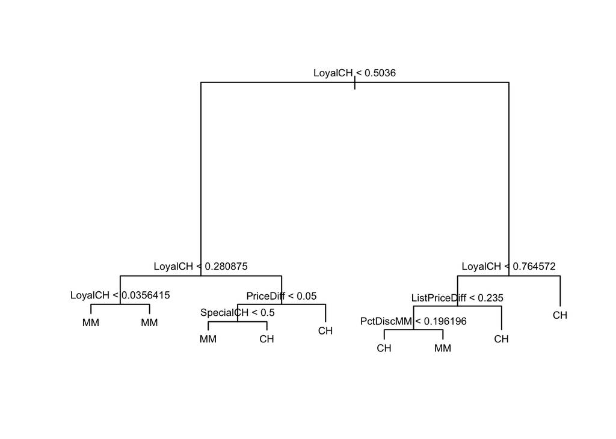

```r
plot(tree_model)
text(tree_model, pretty = 0, cex = 0.7)
```

5. Predict the response on the test data, and produce a confusion matrix comparing the test labels to the predicted test labels. What is the test error rate?

```r
test_pred <- predict(tree_model, test, type = "class")
table(test_pred, test_actual = test$Purchase)
```

```
##          test_actual
## test_pred  CH  MM
##        CH 160  38
##        MM   8  64
```

```r
1 - mean(test_pred == test$Purchase)
```

```
## [1] 0.1703704
```

From the table output above, The error rate is 17%.

6. Apply the cv.tree() function to the training set in order to determine the optimal tree size.

```r
set.seed(1)
cv_tree_model <- cv.tree(tree_model, K = 10, FUN = prune.misclass)
cv_tree_model
```

```
## $size
## [1] 9 8 7 4 2 1
##
## $dev
## [1] 145 145 146 146 167 315
##
## $k
## [1]       -Inf   0.000000   3.000000   4.333333  10.500000 151.000000
##
## $method
## [1] "misclass"
##
## attr(,"class")
## [1] "prune"         "tree.sequence"
```

We can clearly see that the tree of size 8 has produced the minimum misclassification rate and therefore is the optimal tree size.

```r
#data.frame(size = cv_tree_model$size, CV_Error = cv_tree_model$dev / nrow(train)) %>%
 # mutate(min_CV_Error = as.numeric(min(CV_Error) == CV_Error)) %>%
  #ggplot(aes(x = size, y = CV_Error)) +
  #geom_line(col = "grey55") +
  #geom_point(size = 2, aes(col = factor(min_CV_Error))) +
  #scale_x_continuous(breaks = seq(1, 7), minor_breaks = NULL) +
  #scale_y_continuous(labels = scales::percent_format()) +
  #scale_color_manual(values = c("deepskyblue3", "green")) +
  #theme(legend.position = "none") +
  #labs(title = "OJ Dataset - Classification Tree",
   #    subtitle = "Selecting tree 'size' (# of terminal nodes) using cross-validation",
    #   x = "Tree Size",
     #  y = "CV Error")
```

8. Which tree size corresponds to the lowest cross-validated classification error rate?

1. Produce a pruned tree corresponding to the optimal tree size obtained using cross-validation. If cross-validation does not lead to selection of a pruned tree, then create a pruned tree with five terminal nodes.

```r
pruned_tree_model <- prune.tree(tree_model, best = 5)
pruned_tree_model
```

```
## node), split, n, deviance, yval, (yprob)
##       * denotes terminal node
##
##  1) root 800 1073.00 CH ( 0.60625 0.39375 )
##    2) LoyalCH < 0.5036 365  441.60 MM ( 0.29315 0.70685 )
##      4) LoyalCH < 0.280875 177  140.50 MM ( 0.13559 0.86441 ) *
##      5) LoyalCH > 0.280875 188  258.00 MM ( 0.44149 0.55851 ) *
##    3) LoyalCH > 0.5036 435  337.90 CH ( 0.86897 0.13103 )
##      6) LoyalCH < 0.764572 174  201.00 CH ( 0.73563 0.26437 )
##       12) ListPriceDiff < 0.235 72   99.81 MM ( 0.50000 0.50000 ) *
##       13) ListPriceDiff > 0.235 102   65.43 CH ( 0.90196 0.09804 ) *
##      7) LoyalCH > 0.764572 261   91.20 CH ( 0.95785 0.04215 ) *
```

10. Compare the training error rates between the pruned and unpruned trees. Which is higher?

```r
mean(predict(tree_model, type = "class") != train$Purchase)
```

```
## [1] 0.15875
```

```r
mean(predict(pruned_tree_model, type = "class") != train$Purchase)
```

```
## [1] 0.20125
```

Looking at the output, The training errors for normal tree and prune tree is 15% and 20%, respectively, therefore, Training error of pruned tree is higher.

11. Compare the test error rates between the pruned and unpruned trees. Which is higher?

```r
mean(predict(tree_model, type = "class", newdata = test) != test$Purchase)
```

```
## [1] 0.1703704
```

```r
mean(predict(pruned_tree_model, type = "class", newdata = test) != test$Purchase)
```

```
## [1] 0.1740741
```

Comparing the results, we can still say that the test error rates of the prune tree (17.4%) is higher than the normal tree (17%), as the CV results depicts that the trees with more nodes has small error.